# Paper Package

Rasa Gulbinaite

Generated on: Fri Jul 14 15:10:41 2017

# 1 . General description of the task

Paper package for the manuscript **“Individual alpha peak frequency predicts 10 Hz flicker effects on selective attention”** by Gulbinaite, van Viegen, Wieling, Cohen, and VanRullen.

*The task*: modified version of the Eriksen flanker task with target and flankers flickering at different frequencies.

Letters used in the task: E, F, M, N. Two letters were mapped on each hand. Proportion of congruent trials (all letters the same) and incongruent trials (central letter different) were kept at 50%.

On each trial targets and flankers flickered at one of 3 different frequencies, such that the following combinations of tagging frequencies were used:

1. 10Hz T / 7.5Hz F (T = target; F = flankers)
2. 10Hz T /15Hz F
3. 7.5Hz T / 10Hz F
4. 15Hz T / 10Hz F

# 2 . Loading the data, specifying the factors

All numerical predictors (theta power, SSEP amplitude for target and flanker stimuli) were normalized to a Gaussian distribution by ranking the data, scaling between -1 and 1, and taking the inverse hyperbolic tangent (also known as Fisher transform; Cohen “MATLAB for Brain and Cognitive Scientists”, MIT Press, 2017).

```r
setwd('C:/Users/gulbinaite/Desktop/')

dat <- read.table("Gulbinaite_et_al_2017.txt", header=TRUE,as.is=TRUE)

str(dat)
```

```
## 'data.frame':    11799 obs. of  16 variables:
##  $ ID            : int  4 4 4 4 4 4 4 4 4 4 ...
##  $ congr         : int  1 0 1 0 1 1 1 1 1 1 ...
##  $ freq          : int  0 0 0 0 0 0 0 0 0 0 ...
##  $ TFrq          : int  7 7 7 7 7 7 7 7 7 7 ...
##  $ FlFrq         : int  10 10 10 10 10 10 10 10 10 10 ...
##  $ RT            : num  393 501 450 593 268 ...
##  $ amplFfull_norm: num  -0.157 -1.206 -1.312 0.198 -1.479 ...
##  $ amplTfull_norm: num  -0.7246 0.1567 -1.4988 0.0677 -0.2172 ...
##  $ amplFpost_norm: num  -0.719 -0.319 -0.437 -0.501 -1.159 ...
##  $ amplTpost_norm: num  -1.423 -0.344 -1.27 -0.149 -0.424 ...
##  $ amplFpre_norm : num  -0.68406 -1.89868 -0.48207 -0.61877 0.00548 ...
##  $ amplTpre_norm : num  -0.5099 0.1046 -0.8822 -0.0201 1.4234 ...
##  $ alpha_abs     : num  0.5 0.5 0.5 0.5 0.5 0.5 0.5 0.5 0.5 0.5 ...
##  $ alpha         : num  10.5 10.5 10.5 10.5 10.5 10.5 10.5 10.5 10.5 10.5 ...
##  $ cond          : int  3 3 3 3 3 3 3 3 3 3 ...
##  $ theta_norm    : num  0.774 -0.935 -0.69 0.96 -0.127 ...
```

```r
names(dat) <- c(
    "Subj",
    "congr",            # 1: congruent; 0: incongruent
    "freq",             # 1: 10 Hz target; 0: 10 Hz flanker
    "tFrq",             # target frequency in Hz; 3 levels: 7, 10, 15 Hz
    "fFrq",             # flanker frequency in Hz; 3 levels: 7, 10, 15 Hz
    "RT",         #
    "amplFfull_norm",   # SSEP amplitude flankers (based on full trial: 500-2600ms), normalized
    "amplTfull_norm",   # SSEP amplitude targets  (based on full trial: 500-2600ms), normalized
    "amplFpost_norm",   # SSEP amplitude flankers (based on post-stim:  2000-2600ms), normalized
    "amplTpost_norm",   # SSEP amplitude targets  (based on post-stim:  2000-2600ms), normalized
    "amplFpre_norm",    # SSEP amplitude flankers (based on post-stim:  1400-2000ms), normalized
    "amplTpre_norm",    # SSEP amplitude targets  (based on post-stim:  1400-2000ms), normalized
    "alphaABS",         # ABS distance from occ alpha peak to 10 Hz
    "alpha",              # alpha  peak frequency
    "cond",               # cond: 1 = 10T/7.5F; 2 = 10T/15F; 3 = 7.5T/10F; 4 = 15T/10F
    "theta_norm"        # theta band power, normalized
   )

# Log-transform RTs
dat$RT.log <- log(dat$RT)


# Factors
dat$Subj <- as.factor(dat$Subj)
dat$freq <- as.factor(dat$freq)

dat$tFrq <- as.factor(dat$tFrq)
dat$fFrq <- as.factor(dat$fFrq)

dat$congr <- as.factor(dat$congr)
dat$cond <- as.factor(dat$cond)
```

# 3 . Loading necessary libraries

```r
library(lme4)
```

```r
library(car)
library(sjPlot)
```

# 4 . Can congruency alone explain log-RT variability or adding condition as an additional fixed factor explains more?

```r
lme1 <- lmer(RT.log ~ congr + (1 | Subj), data=dat, REML = FALSE)
lme2 <- lmer(RT.log ~ congr + cond + (1 | Subj), data=dat, REML = FALSE)

anova(lme1, lme2)
```

```
## Data: dat
## Models:
## lme1: RT.log ~ congr + (1 | Subj)
## lme2: RT.log ~ congr + cond + (1 | Subj)
##      Df     AIC     BIC logLik deviance Chisq Chi Df Pr(>Chisq)
## lme1  4 -5603.3 -5573.8 2805.6  -5611.3
## lme2  7 -5657.5 -5605.9 2835.7  -5671.5 60.23      3  5.249e-13 ***
## ---
## Signif. codes:  0 '***' 0.001 '**' 0.01 '*' 0.05 '.' 0.1 ' ' 1
```

**INTERIM CONCLUSION:** Yes, a model with condition added is preferred, i.e. lme2 is the best-fitting model so far.

## 4.1 . Does the interaction between condition and congruency explain more variance, or just the main effects are enough?

```r
lme2.a <- lmer(RT.log ~ congr*cond + (1 | Subj), data=dat, REML = FALSE)

anova(lme2, lme2.a)
```

```
## Data: dat
## Models:
## lme2: RT.log ~ congr + cond + (1 | Subj)
## lme2.a: RT.log ~ congr * cond + (1 | Subj)
##        Df     AIC     BIC logLik deviance  Chisq Chi Df Pr(>Chisq)
## lme2    7 -5657.5 -5605.9 2835.7  -5671.5
## lme2.a 10 -5652.0 -5578.3 2836.0  -5672.0 0.5261      3     0.9131
```

**INTERIM CONCLUSION:** Just the main effects of congruency and condition are enough.

## 4.2 . Are the random effects of congruency and/or condition necessary?

```r
lme2 <- lmer(RT.log ~ congr + cond + (1 | Subj), data=dat, REML = TRUE)
lme2.b <- lmer(RT.log ~ congr + cond + (1 + cond| Subj), data=dat, REML = TRUE)
lme2.c <- lmer(RT.log ~ congr + cond + (1 + congr| Subj), data=dat, REML = TRUE)
lme2.d <- lmer(RT.log ~ congr + cond + (1 + congr + cond| Subj), data=dat, REML = TRUE)

anova(lme2.b, lme2, refit = FALSE)
```

```
## Data: dat
## Models:
## lme2: RT.log ~ congr + cond + (1 | Subj)
## lme2.b: RT.log ~ congr + cond + (1 + cond | Subj)
##        Df     AIC     BIC logLik deviance  Chisq Chi Df Pr(>Chisq)
## lme2    7 -5615.3 -5563.7 2814.7  -5629.3
## lme2.b 16 -5635.8 -5517.8 2833.9  -5667.8 38.428      9  1.461e-05 ***
## ---
## Signif. codes:  0 '***' 0.001 '**' 0.01 '*' 0.05 '.' 0.1 ' ' 1
```

```r
anova(lme2.c, lme2, refit = FALSE)
```

```
## Data: dat
## Models:
## lme2: RT.log ~ congr + cond + (1 | Subj)
## lme2.c: RT.log ~ congr + cond + (1 + congr | Subj)
##        Df     AIC     BIC logLik deviance  Chisq Chi Df Pr(>Chisq)
## lme2    7 -5615.3 -5563.7 2814.7  -5629.3
## lme2.c  9 -5619.2 -5552.8 2818.6  -5637.2 7.8759      2    0.01949 *
## ---
## Signif. codes:  0 '***' 0.001 '**' 0.01 '*' 0.05 '.' 0.1 ' ' 1
```

```r
anova(lme2.d, lme2, refit = FALSE)
```

```
## Data: dat
## Models:
## lme2: RT.log ~ congr + cond + (1 | Subj)
## lme2.d: RT.log ~ congr + cond + (1 + congr + cond | Subj)
##        Df     AIC     BIC logLik deviance  Chisq Chi Df Pr(>Chisq)
## lme2    7 -5615.3 -5563.7 2814.7  -5629.3
## lme2.d 21 -5635.6 -5480.7 2838.8  -5677.6 48.295     14  1.175e-05 ***
## ---
## Signif. codes:  0 '***' 0.001 '**' 0.01 '*' 0.05 '.' 0.1 ' ' 1
```

```r
anova(lme2.b, lme2.c, refit = FALSE)
```

```
## Data: dat
## Models:
## lme2.c: RT.log ~ congr + cond + (1 + congr | Subj)
## lme2.b: RT.log ~ congr + cond + (1 + cond | Subj)
##        Df     AIC     BIC logLik deviance  Chisq Chi Df Pr(>Chisq)
## lme2.c  9 -5619.2 -5552.8 2818.6  -5637.2
## lme2.b 16 -5635.8 -5517.8 2833.9  -5667.8 30.552      7  7.519e-05 ***
## ---
## Signif. codes:  0 '***' 0.001 '**' 0.01 '*' 0.05 '.' 0.1 ' ' 1
```

```r
anova(lme2.b, lme2.d, refit = FALSE)
```

```
## Data: dat
## Models:
## lme2.b: RT.log ~ congr + cond + (1 + cond | Subj)
## lme2.d: RT.log ~ congr + cond + (1 + congr + cond | Subj)
##        Df     AIC     BIC logLik deviance  Chisq Chi Df Pr(>Chisq)
## lme2.b 16 -5635.8 -5517.8 2833.9  -5667.8
## lme2.d 21 -5635.6 -5480.7 2838.8  -5677.6 9.8669      5     0.0791 .
## ---
## Signif. codes:  0 '***' 0.001 '**' 0.01 '*' 0.05 '.' 0.1 ' ' 1
```

**INTERIM CONCLUSION:** lme2.b is the best model so far, including a random effect of conidtion improves the model fit. Adding both condition and congruency (lme2.d) is not superior to having just condition (simpler model, i.e. **lme2.b**).

# 5 . Does adding distance to individual alpha peak frequency (alphaABS) explain more variance?

alphaABS = ABS(IAF-10) where IAF is individual alpha peak frequency at occipital alpha sources (see Methods section of the paper).

```r
lme2.b <- lmer(RT.log ~ congr + cond + (1 + cond| Subj), data=dat, REML = FALSE)
lme3 <- lmer(RT.log ~ congr + cond + alphaABS + (1 + cond| Subj) , data=dat, REML = FALSE)

anova(lme2.b, lme3)
```

```
## Data: dat
## Models:
## lme2.b: RT.log ~ congr + cond + (1 + cond | Subj)
## lme3: RT.log ~ congr + cond + alphaABS + (1 + cond | Subj)
##        Df     AIC     BIC logLik deviance  Chisq Chi Df Pr(>Chisq)
## lme2.b 16 -5675.5 -5557.5 2853.7  -5707.5
## lme3   17 -5678.5 -5553.1 2856.2  -5712.5 5.0132      1    0.02515 *
## ---
## Signif. codes:  0 '***' 0.001 '**' 0.01 '*' 0.05 '.' 0.1 ' ' 1
```

**INTERIM CONCLUSION:** Adding distance to the occipital alpha peak (alphaABS) improved the model fit. **lme3** is the best-fitting model so far.

## 5.1 . Is the main effect of alphaABS sufficient or the interaction with congruency and/or condition explains additional variance?

```r
lme3.a <- lmer(RT.log ~ congr*alphaABS + cond*alphaABS + (1 + cond| Subj), data=dat, REML = FALSE)
lme3.b <- lmer(RT.log ~ congr + cond*alphaABS + (1 + cond| Subj), data=dat, REML = FALSE)
lme3.c <- lmer(RT.log ~ congr*alphaABS + cond + (1 + cond| Subj), data=dat, REML = FALSE)

anova(lme3, lme3.a)
```

```
## Data: dat
## Models:
## lme3: RT.log ~ congr + cond + alphaABS + (1 + cond | Subj)
## lme3.a: RT.log ~ congr * alphaABS + cond * alphaABS + (1 + cond | Subj)
##        Df     AIC     BIC logLik deviance  Chisq Chi Df Pr(>Chisq)
## lme3   17 -5678.5 -5553.1 2856.2  -5712.5
## lme3.a 21 -5677.0 -5522.1 2859.5  -5719.0 6.4812      4      0.166
```

```r
anova(lme3, lme3.b)
```

```
## Data: dat
## Models:
## lme3: RT.log ~ congr + cond + alphaABS + (1 + cond | Subj)
## lme3.b: RT.log ~ congr + cond * alphaABS + (1 + cond | Subj)
##        Df     AIC     BIC logLik deviance Chisq Chi Df Pr(>Chisq)
## lme3   17 -5678.5 -5553.1 2856.2  -5712.5
## lme3.b 20 -5673.1 -5525.5 2856.5  -5713.1 0.581      3     0.9008
```

```r
anova(lme3, lme3.c)
```

```
## Data: dat
## Models:
## lme3: RT.log ~ congr + cond + alphaABS + (1 + cond | Subj)
## lme3.c: RT.log ~ congr * alphaABS + cond + (1 + cond | Subj)
##        Df     AIC     BIC logLik deviance  Chisq Chi Df Pr(>Chisq)
## lme3   17 -5678.5 -5553.1 2856.2  -5712.5
## lme3.c 18 -5682.3 -5549.6 2859.2  -5718.3 5.8637      1    0.01546 *
## ---
## Signif. codes:  0 '***' 0.001 '**' 0.01 '*' 0.05 '.' 0.1 ' ' 1
```

**INTERIM CONCLUSION:** Adding alphaABS interaction with congruency improved the model fit. **lme3.c** is the best-fitting model so far.

# 6 . Does adding post-stimulus or pre-stimulus SSEP target and flankers’ amplitude improve log-RT predictability?

Post-stimulus SSEP amplitudes for target and flankers: SSEP amplitude in a 2000-2600 ms window (where 2000 ms is the stimulus onset). Pre-stimulus SSEP amplitudes: SSEP amplitude in a 1400-2000 ms window (i.e. prior to imperative stimulus).

```r
lme4 <- lmer(RT.log ~ congr*alphaABS + cond + amplTpost_norm + (1 + cond| Subj) , data=dat, REML = FALSE)
lme4.a <- lmer(RT.log ~ congr*alphaABS + cond + amplTpost_norm + amplFpost_norm + (1 + cond| Subj) , data=dat, REML = FALSE)
lme4.1 <- lmer(RT.log ~ congr*alphaABS + cond + amplTpre_norm + amplFpre_norm + (1 + cond| Subj), data=dat, REML = FALSE)

anova(lme3.c, lme4)
```

```
## Data: dat
## Models:
## lme3.c: RT.log ~ congr * alphaABS + cond + (1 + cond | Subj)
## lme4: RT.log ~ congr * alphaABS + cond + amplTpost_norm + (1 + cond |
## lme4:     Subj)
##        Df     AIC     BIC logLik deviance  Chisq Chi Df Pr(>Chisq)
## lme3.c 18 -5682.3 -5549.6 2859.2  -5718.3
## lme4   19 -5761.0 -5620.9 2899.5  -5799.0 80.653      1  < 2.2e-16 ***
## ---
## Signif. codes:  0 '***' 0.001 '**' 0.01 '*' 0.05 '.' 0.1 ' ' 1
```

```r
anova(lme4, lme4.a)
```

```
## Data: dat
## Models:
## lme4: RT.log ~ congr * alphaABS + cond + amplTpost_norm + (1 + cond |
## lme4:     Subj)
## lme4.a: RT.log ~ congr * alphaABS + cond + amplTpost_norm + amplFpost_norm +
## lme4.a:     (1 + cond | Subj)
##        Df     AIC     BIC logLik deviance  Chisq Chi Df Pr(>Chisq)
## lme4   19 -5761.0 -5620.9 2899.5  -5799.0
## lme4.a 20 -5796.9 -5649.4 2918.4  -5836.9 37.894      1   7.47e-10 ***
## ---
## Signif. codes:  0 '***' 0.001 '**' 0.01 '*' 0.05 '.' 0.1 ' ' 1
```

```r
anova(lme4.a, lme4.1)
```

```
## Data: dat
## Models:
## lme4.a: RT.log ~ congr * alphaABS + cond + amplTpost_norm + amplFpost_norm +
## lme4.a:     (1 + cond | Subj)
## lme4.1: RT.log ~ congr * alphaABS + cond + amplTpre_norm + amplFpre_norm +
## lme4.1:     (1 + cond | Subj)
##        Df     AIC     BIC logLik deviance Chisq Chi Df Pr(>Chisq)
## lme4.a 20 -5796.9 -5649.4 2918.4  -5836.9
## lme4.1 20 -5679.1 -5531.5 2859.5  -5719.1     0      0          1
```

## 6.1 . Are random effects of SSEP target and flankers amplitude necessary?

```r
lme4.a <- lmer(RT.log ~ congr*alphaABS + cond + amplTpost_norm + amplFpost_norm + (1 + cond| Subj) , data=dat, REML = TRUE)

lme4.b <- lmer(RT.log ~ congr*alphaABS + cond + amplTpost_norm + amplFpost_norm + (1 + cond| Subj) + (0 + amplTpost_norm|Subj), data=dat, REML = TRUE)
lme4.c <- lmer(RT.log ~ congr*alphaABS + cond + amplTpost_norm + amplFpost_norm + (1 + cond + amplTpost_norm|Subj), data=dat, REML = TRUE)
lme4.d <- lmer(RT.log ~ congr*alphaABS + cond + amplTpost_norm + amplFpost_norm + (1 + cond| Subj) + (0 + amplTpost_norm|Subj)+ (0 + amplFpost_norm|Subj), data=dat, REML = TRUE)
lme4.e <- lmer(RT.log ~ congr*alphaABS + cond + amplTpost_norm + amplFpost_norm + (1 + cond + amplFpost_norm| Subj) + (0 + amplTpost_norm|Subj), data=dat, REML = TRUE)
lme4.f <- lmer(RT.log ~ congr*alphaABS + cond + amplTpost_norm + amplFpost_norm + (1 + cond | Subj) + (0 + amplTpost_norm + amplFpost_norm|Subj), data=dat, REML = TRUE)

anova(lme4.a,lme4.b,refit=FALSE)
```

```
## Data: dat
## Models:
## lme4.a: RT.log ~ congr * alphaABS + cond + amplTpost_norm + amplFpost_norm +
## lme4.a:     (1 + cond | Subj)
## lme4.b: RT.log ~ congr * alphaABS + cond + amplTpost_norm + amplFpost_norm +
## lme4.b:     (1 + cond | Subj) + (0 + amplTpost_norm | Subj)
##        Df     AIC     BIC logLik deviance  Chisq Chi Df Pr(>Chisq)
## lme4.a 20 -5721.9 -5574.4 2880.9  -5761.9
## lme4.b 21 -5754.1 -5599.2 2898.1  -5796.1 34.241      1  4.868e-09 ***
## ---
## Signif. codes:  0 '***' 0.001 '**' 0.01 '*' 0.05 '.' 0.1 ' ' 1
```

```r
anova(lme4.b,lme4.c,refit=FALSE)
```

```
## Data: dat
## Models:
## lme4.b: RT.log ~ congr * alphaABS + cond + amplTpost_norm + amplFpost_norm +
## lme4.b:     (1 + cond | Subj) + (0 + amplTpost_norm | Subj)
## lme4.c: RT.log ~ congr * alphaABS + cond + amplTpost_norm + amplFpost_norm +
## lme4.c:     (1 + cond + amplTpost_norm | Subj)
##        Df     AIC     BIC logLik deviance  Chisq Chi Df Pr(>Chisq)
## lme4.b 21 -5754.1 -5599.2 2898.1  -5796.1
## lme4.c 25 -5753.2 -5568.8 2901.6  -5803.2 7.0884      4     0.1313
```

```r
anova(lme4.b,lme4.d,refit=FALSE)
```

```
## Data: dat
## Models:
## lme4.b: RT.log ~ congr * alphaABS + cond + amplTpost_norm + amplFpost_norm +
## lme4.b:     (1 + cond | Subj) + (0 + amplTpost_norm | Subj)
## lme4.d: RT.log ~ congr * alphaABS + cond + amplTpost_norm + amplFpost_norm +
## lme4.d:     (1 + cond | Subj) + (0 + amplTpost_norm | Subj) + (0 + amplFpost_norm |
## lme4.d:     Subj)
##        Df     AIC     BIC logLik deviance  Chisq Chi Df Pr(>Chisq)
## lme4.b 21 -5754.1 -5599.2 2898.1  -5796.1
## lme4.d 22 -5758.5 -5596.2 2901.2  -5802.5 6.3736      1    0.01158 *
## ---
## Signif. codes:  0 '***' 0.001 '**' 0.01 '*' 0.05 '.' 0.1 ' ' 1
```

```r
anova(lme4.d,lme4.e,refit=FALSE)
```

```
## Data: dat
## Models:
## lme4.d: RT.log ~ congr * alphaABS + cond + amplTpost_norm + amplFpost_norm +
## lme4.d:     (1 + cond | Subj) + (0 + amplTpost_norm | Subj) + (0 + amplFpost_norm |
## lme4.d:     Subj)
## lme4.e: RT.log ~ congr * alphaABS + cond + amplTpost_norm + amplFpost_norm +
## lme4.e:     (1 + cond + amplFpost_norm | Subj) + (0 + amplTpost_norm |
## lme4.e:     Subj)
##        Df     AIC     BIC logLik deviance  Chisq Chi Df Pr(>Chisq)
## lme4.d 22 -5758.5 -5596.2 2901.2  -5802.5
## lme4.e 26 -5760.1 -5568.3 2906.0  -5812.1 9.5866      4      0.048 *
## ---
## Signif. codes:  0 '***' 0.001 '**' 0.01 '*' 0.05 '.' 0.1 ' ' 1
```

```r
anova(lme4.d,lme4.f,refit=FALSE)
```

```
## Data: dat
## Models:
## lme4.d: RT.log ~ congr * alphaABS + cond + amplTpost_norm + amplFpost_norm +
## lme4.d:     (1 + cond | Subj) + (0 + amplTpost_norm | Subj) + (0 + amplFpost_norm |
## lme4.d:     Subj)
## lme4.f: RT.log ~ congr * alphaABS + cond + amplTpost_norm + amplFpost_norm +
## lme4.f:     (1 + cond | Subj) + (0 + amplTpost_norm + amplFpost_norm |
## lme4.f:     Subj)
##        Df     AIC     BIC logLik deviance  Chisq Chi Df Pr(>Chisq)
## lme4.d 22 -5758.5 -5596.2 2901.2  -5802.5
## lme4.f 23 -5772.8 -5603.2 2909.4  -5818.8 16.316      1   5.36e-05 ***
## ---
## Signif. codes:  0 '***' 0.001 '**' 0.01 '*' 0.05 '.' 0.1 ' ' 1
```

**INTERIM CONCLUSION:** Yes, random effect of both SSEP amplitude for targets and flankers, and covariance between them improves the model fit. **lme4.f** is the best-fitting model so far.

## 6.2 . Does target and flankers’ SSEP amplitude interaction with congruency explain more variance?

```r
lme4.f <- lmer(RT.log ~ congr*alphaABS + cond + amplTpost_norm + amplFpost_norm + (1 + cond | Subj) + (0 + amplTpost_norm + amplFpost_norm|Subj), data=dat, REML = FALSE)

lme5.a <- lmer(RT.log ~ congr*alphaABS + cond + amplTpost_norm*congr + amplFpost_norm*congr + (1 + cond| Subj) + (0 + amplTpost_norm + amplFpost_norm|Subj), data=dat, REML = FALSE)
lme5.b <- lmer(RT.log ~ congr*alphaABS + cond + amplTpost_norm*congr + amplFpost_norm + (1 + cond| Subj) + (0 + amplTpost_norm + amplFpost_norm|Subj), data=dat, REML = FALSE)
lme5.c <- lmer(RT.log ~ congr*alphaABS + cond + amplTpost_norm + amplFpost_norm*congr + (1 + cond| Subj) + (0 + amplTpost_norm + amplFpost_norm|Subj), data=dat, REML = FALSE)

anova(lme4.f, lme5.a)
```

```
## Data: dat
## Models:
## lme4.f: RT.log ~ congr * alphaABS + cond + amplTpost_norm + amplFpost_norm +
## lme4.f:     (1 + cond | Subj) + (0 + amplTpost_norm + amplFpost_norm |
## lme4.f:     Subj)
## lme5.a: RT.log ~ congr * alphaABS + cond + amplTpost_norm * congr + amplFpost_norm *
## lme5.a:     congr + (1 + cond | Subj) + (0 + amplTpost_norm + amplFpost_norm |
## lme5.a:     Subj)
##        Df     AIC     BIC logLik deviance  Chisq Chi Df Pr(>Chisq)
## lme4.f 23 -5846.2 -5676.5 2946.1  -5892.2
## lme5.a 25 -5846.0 -5661.6 2948.0  -5896.0 3.8199      2     0.1481
```

```r
anova(lme4.f, lme5.b)
```

```
## Data: dat
## Models:
## lme4.f: RT.log ~ congr * alphaABS + cond + amplTpost_norm + amplFpost_norm +
## lme4.f:     (1 + cond | Subj) + (0 + amplTpost_norm + amplFpost_norm |
## lme4.f:     Subj)
## lme5.b: RT.log ~ congr * alphaABS + cond + amplTpost_norm * congr + amplFpost_norm +
## lme5.b:     (1 + cond | Subj) + (0 + amplTpost_norm + amplFpost_norm |
## lme5.b:     Subj)
##        Df     AIC     BIC logLik deviance  Chisq Chi Df Pr(>Chisq)
## lme4.f 23 -5846.2 -5676.5 2946.1  -5892.2
## lme5.b 24 -5845.7 -5668.7 2946.8  -5893.7 1.5251      1     0.2169
```

```r
anova(lme4.f, lme5.c)
```

```
## Data: dat
## Models:
## lme4.f: RT.log ~ congr * alphaABS + cond + amplTpost_norm + amplFpost_norm +
## lme4.f:     (1 + cond | Subj) + (0 + amplTpost_norm + amplFpost_norm |
## lme4.f:     Subj)
## lme5.c: RT.log ~ congr * alphaABS + cond + amplTpost_norm + amplFpost_norm *
## lme5.c:     congr + (1 + cond | Subj) + (0 + amplTpost_norm + amplFpost_norm |
## lme5.c:     Subj)
##        Df     AIC     BIC logLik deviance  Chisq Chi Df Pr(>Chisq)
## lme4.f 23 -5846.2 -5676.5 2946.1  -5892.2
## lme5.c 24 -5846.5 -5669.5 2947.3  -5894.5 2.3773      1     0.1231
```

**INTERIM CONCLUSION:** SSEP amplitude interaction with congruency is not necessary. **lme4.f** is the best-fitting model so far.

## 6.3 . Does tagret and flankers’ SSEP amplitude interaction with condition explain more variance?

```r
lme6.a <- lmer(RT.log ~ congr*alphaABS + amplTpost_norm*cond + amplFpost_norm*cond + (1 + cond| Subj) + (0 + amplTpost_norm + amplFpost_norm|Subj), data=dat, REML = FALSE)
lme6.b <- lmer(RT.log ~ congr*alphaABS + amplTpost_norm*cond + amplFpost_norm + (1 + cond| Subj) + (0 + amplTpost_norm + amplFpost_norm|Subj), data=dat, REML = FALSE)
lme6.c <- lmer(RT.log ~ congr*alphaABS + amplTpost_norm + amplFpost_norm*cond + (1 + cond| Subj) + (0 + amplTpost_norm + amplFpost_norm|Subj), data=dat, REML = FALSE)

anova(lme4.f, lme6.a)
```

```
## Data: dat
## Models:
## lme4.f: RT.log ~ congr * alphaABS + cond + amplTpost_norm + amplFpost_norm +
## lme4.f:     (1 + cond | Subj) + (0 + amplTpost_norm + amplFpost_norm |
## lme4.f:     Subj)
## lme6.a: RT.log ~ congr * alphaABS + amplTpost_norm * cond + amplFpost_norm *
## lme6.a:     cond + (1 + cond | Subj) + (0 + amplTpost_norm + amplFpost_norm |
## lme6.a:     Subj)
##        Df     AIC     BIC logLik deviance  Chisq Chi Df Pr(>Chisq)
## lme4.f 23 -5846.2 -5676.5 2946.1  -5892.2
## lme6.a 29 -5890.7 -5676.8 2974.3  -5948.7 56.549      6  2.254e-10 ***
## ---
## Signif. codes:  0 '***' 0.001 '**' 0.01 '*' 0.05 '.' 0.1 ' ' 1
```

```r
anova(lme4.f, lme6.b)
```

```
## Data: dat
## Models:
## lme4.f: RT.log ~ congr * alphaABS + cond + amplTpost_norm + amplFpost_norm +
## lme4.f:     (1 + cond | Subj) + (0 + amplTpost_norm + amplFpost_norm |
## lme4.f:     Subj)
## lme6.b: RT.log ~ congr * alphaABS + amplTpost_norm * cond + amplFpost_norm +
## lme6.b:     (1 + cond | Subj) + (0 + amplTpost_norm + amplFpost_norm |
## lme6.b:     Subj)
##        Df     AIC     BIC logLik deviance  Chisq Chi Df Pr(>Chisq)
## lme4.f 23 -5846.2 -5676.5 2946.1  -5892.2
## lme6.b 26 -5876.2 -5684.4 2964.1  -5928.2 36.052      3    7.3e-08 ***
## ---
## Signif. codes:  0 '***' 0.001 '**' 0.01 '*' 0.05 '.' 0.1 ' ' 1
```

```r
anova(lme4.f, lme6.c)
```

```
## Data: dat
## Models:
## lme4.f: RT.log ~ congr * alphaABS + cond + amplTpost_norm + amplFpost_norm +
## lme4.f:     (1 + cond | Subj) + (0 + amplTpost_norm + amplFpost_norm |
## lme4.f:     Subj)
## lme6.c: RT.log ~ congr * alphaABS + amplTpost_norm + amplFpost_norm *
## lme6.c:     cond + (1 + cond | Subj) + (0 + amplTpost_norm + amplFpost_norm |
## lme6.c:     Subj)
##        Df     AIC     BIC logLik deviance Chisq Chi Df Pr(>Chisq)
## lme4.f 23 -5846.2 -5676.5 2946.1  -5892.2
## lme6.c 26 -5860.7 -5669.0 2956.4  -5912.7 20.57      3  0.0001293 ***
## ---
## Signif. codes:  0 '***' 0.001 '**' 0.01 '*' 0.05 '.' 0.1 ' ' 1
```

```r
anova(lme6.a, lme6.b)
```

```
## Data: dat
## Models:
## lme6.b: RT.log ~ congr * alphaABS + amplTpost_norm * cond + amplFpost_norm +
## lme6.b:     (1 + cond | Subj) + (0 + amplTpost_norm + amplFpost_norm |
## lme6.b:     Subj)
## lme6.a: RT.log ~ congr * alphaABS + amplTpost_norm * cond + amplFpost_norm *
## lme6.a:     cond + (1 + cond | Subj) + (0 + amplTpost_norm + amplFpost_norm |
## lme6.a:     Subj)
##        Df     AIC     BIC logLik deviance  Chisq Chi Df Pr(>Chisq)
## lme6.b 26 -5876.2 -5684.4 2964.1  -5928.2
## lme6.a 29 -5890.7 -5676.8 2974.3  -5948.7 20.497      3  0.0001339 ***
## ---
## Signif. codes:  0 '***' 0.001 '**' 0.01 '*' 0.05 '.' 0.1 ' ' 1
```

```r
anova(lme6.a, lme6.c)
```

```
## Data: dat
## Models:
## lme6.c: RT.log ~ congr * alphaABS + amplTpost_norm + amplFpost_norm *
## lme6.c:     cond + (1 + cond | Subj) + (0 + amplTpost_norm + amplFpost_norm |
## lme6.c:     Subj)
## lme6.a: RT.log ~ congr * alphaABS + amplTpost_norm * cond + amplFpost_norm *
## lme6.a:     cond + (1 + cond | Subj) + (0 + amplTpost_norm + amplFpost_norm |
## lme6.a:     Subj)
##        Df     AIC     BIC logLik deviance  Chisq Chi Df Pr(>Chisq)
## lme6.c 26 -5860.7 -5669.0 2956.4  -5912.7
## lme6.a 29 -5890.7 -5676.8 2974.3  -5948.7 35.979      3  7.564e-08 ***
## ---
## Signif. codes:  0 '***' 0.001 '**' 0.01 '*' 0.05 '.' 0.1 ' ' 1
```

**INTERIM CONCLUSION:** SSEP amplitude interaction with condition is necessary. **lme6.a** is the best-fitting model so far.

## 6.4 . Are additional random effects of interaction between SSEP target amplitude (and/or SSEP flankers amplitude) and condition necessary?

```r
lme6.a <- lmer(RT.log ~ congr*alphaABS + amplTpost_norm*cond + amplFpost_norm*cond + (1 + cond| Subj) + (0 + amplTpost_norm + amplFpost_norm|Subj), data=dat, REML = TRUE)

lme6.a1 <- lmer(RT.log ~ congr*alphaABS + amplTpost_norm*cond + amplFpost_norm*cond + (1 + cond*amplTpost_norm| Subj) + (0  + amplFpost_norm|Subj), data=dat, REML = TRUE)
lme6.a2 <- lmer(RT.log ~ congr*alphaABS + amplTpost_norm*cond + amplFpost_norm*cond + (1 + cond*amplFpost_norm| Subj) + (0  + amplTpost_norm|Subj), data=dat, REML = TRUE)
```

**INTERIM CONCLUSION:** Just the random effect of target and flanker SSEP amplitude and covariance between them is sufficient. The more complex models do not converge.

# 7 . Does adding normalized theta power explain more?

Inclusion of theta power as an additional factor is motivated by the fact that Eriksen flanker task is a conflict task and elicits strong mid-frontal theta power (for a review see, Cohen 2014 TINS; Cavanagh & Frank, 2014, TICS). Moreover, theta power is correlated with single-trial RTs (Cohen & Cavanagh, 2011; Gulbinaite et al., 2014).

```r
lme7 <- lmer(RT.log ~ congr*alphaABS + amplTpost_norm*cond + amplFpost_norm*cond + theta_norm + (1 + cond| Subj) + (0 + amplTpost_norm + amplFpost_norm|Subj), data=dat, REML = FALSE)
anova(lme6.a, lme7)
```

```
## refitting model(s) with ML (instead of REML)
```

```
## Data: dat
## Models:
## lme6.a: RT.log ~ congr * alphaABS + amplTpost_norm * cond + amplFpost_norm *
## lme6.a:     cond + (1 + cond | Subj) + (0 + amplTpost_norm + amplFpost_norm |
## lme6.a:     Subj)
## lme7: RT.log ~ congr * alphaABS + amplTpost_norm * cond + amplFpost_norm *
## lme7:     cond + theta_norm + (1 + cond | Subj) + (0 + amplTpost_norm +
## lme7:     amplFpost_norm | Subj)
##        Df     AIC     BIC logLik deviance  Chisq Chi Df Pr(>Chisq)
## lme6.a 29 -5890.7 -5676.8 2974.3  -5948.7
## lme7   30 -6007.7 -5786.4 3033.8  -6067.7 118.99      1  < 2.2e-16 ***
## ---
## Signif. codes:  0 '***' 0.001 '**' 0.01 '*' 0.05 '.' 0.1 ' ' 1
```

**INTERIM CONCLUSION:** Yes, adding theta power as an additional fixed factor improves the model fit. **lme7** is the preferred model.

## 7.1 . Is the random effect of theta power necessary?

```r
lme7 <- lmer(RT.log ~ congr*alphaABS + amplTpost_norm*cond + amplFpost_norm*cond + theta_norm + (1 + cond| Subj) + (0 + amplTpost_norm + amplFpost_norm|Subj), data=dat, REML = TRUE)
lme7.a <- lmer(RT.log ~ congr*alphaABS + amplTpost_norm*cond + amplFpost_norm*cond + theta_norm + (1 + cond| Subj) + (0 + amplTpost_norm + amplFpost_norm|Subj) + (0 + theta_norm|Subj), data=dat, REML = TRUE)
lme7.b <- lmer(RT.log ~ congr*alphaABS + amplTpost_norm*cond + amplFpost_norm*cond + theta_norm + (1 + cond + theta_norm| Subj) + (0 + amplTpost_norm + amplFpost_norm|Subj), data=dat, REML = TRUE)
lme7.c <- lmer(RT.log ~ congr*alphaABS + amplTpost_norm*cond + amplFpost_norm*cond + theta_norm + (1 + cond| Subj) + (0 + amplTpost_norm + amplFpost_norm + theta_norm|Subj), data=dat, REML = TRUE)

anova(lme7, lme7.a, refit = FALSE)
```

```
## Data: dat
## Models:
## lme7: RT.log ~ congr * alphaABS + amplTpost_norm * cond + amplFpost_norm *
## lme7:     cond + theta_norm + (1 + cond | Subj) + (0 + amplTpost_norm +
## lme7:     amplFpost_norm | Subj)
## lme7.a: RT.log ~ congr * alphaABS + amplTpost_norm * cond + amplFpost_norm *
## lme7.a:     cond + theta_norm + (1 + cond | Subj) + (0 + amplTpost_norm +
## lme7.a:     amplFpost_norm | Subj) + (0 + theta_norm | Subj)
##        Df     AIC     BIC logLik deviance  Chisq Chi Df Pr(>Chisq)
## lme7   30 -5870.8 -5649.6 2965.4  -5930.8
## lme7.a 31 -6029.6 -5801.0 3045.8  -6091.6 160.79      1  < 2.2e-16 ***
## ---
## Signif. codes:  0 '***' 0.001 '**' 0.01 '*' 0.05 '.' 0.1 ' ' 1
```

```r
anova(lme7.a, lme7.b, refit = FALSE)
```

```
## Data: dat
## Models:
## lme7.a: RT.log ~ congr * alphaABS + amplTpost_norm * cond + amplFpost_norm *
## lme7.a:     cond + theta_norm + (1 + cond | Subj) + (0 + amplTpost_norm +
## lme7.a:     amplFpost_norm | Subj) + (0 + theta_norm | Subj)
## lme7.b: RT.log ~ congr * alphaABS + amplTpost_norm * cond + amplFpost_norm *
## lme7.b:     cond + theta_norm + (1 + cond + theta_norm | Subj) + (0 +
## lme7.b:     amplTpost_norm + amplFpost_norm | Subj)
##        Df     AIC     BIC logLik deviance  Chisq Chi Df Pr(>Chisq)
## lme7.a 31 -6029.6 -5801.0 3045.8  -6091.6
## lme7.b 35 -6025.4 -5767.2 3047.7  -6095.4 3.7391      4     0.4425
```

```r
anova(lme7.a, lme7.c, refit = FALSE)
```

```
## Data: dat
## Models:
## lme7.a: RT.log ~ congr * alphaABS + amplTpost_norm * cond + amplFpost_norm *
## lme7.a:     cond + theta_norm + (1 + cond | Subj) + (0 + amplTpost_norm +
## lme7.a:     amplFpost_norm | Subj) + (0 + theta_norm | Subj)
## lme7.c: RT.log ~ congr * alphaABS + amplTpost_norm * cond + amplFpost_norm *
## lme7.c:     cond + theta_norm + (1 + cond | Subj) + (0 + amplTpost_norm +
## lme7.c:     amplFpost_norm + theta_norm | Subj)
##        Df     AIC     BIC logLik deviance  Chisq Chi Df Pr(>Chisq)
## lme7.a 31 -6029.6 -5801.0 3045.8  -6091.6
## lme7.c 33 -6027.8 -5784.4 3046.9  -6093.8 2.2151      2     0.3304
```

**INTERIM CONCLUSION:** Yes, random effect of theta power improves the model fit. **lme7.a** is the best-fitting model so far.

## 7.2 . Is the interaction between theta and condition and/or theta and congruency necessary, or just the main effect is sufficient?

```r
lme7.a <- lmer(RT.log ~ congr*alphaABS + amplTpost_norm*cond + amplFpost_norm*cond + theta_norm + (1 + cond| Subj) + (0 + amplTpost_norm + amplFpost_norm|Subj) + (0 + theta_norm|Subj), data=dat, REML = FALSE)
lme8.a <- lmer(RT.log ~ congr*alphaABS + amplTpost_norm*cond + amplFpost_norm*cond + theta_norm*congr + (1 + cond| Subj) + (0 + amplTpost_norm + amplFpost_norm|Subj) + (0 + theta_norm|Subj), data=dat, REML = FALSE)
lme8.b <- lmer(RT.log ~ congr*alphaABS + amplTpost_norm*cond + amplFpost_norm*cond + theta_norm*cond + (1 + cond| Subj) + (0 + amplTpost_norm + amplFpost_norm|Subj) + (0 + theta_norm|Subj), data=dat, REML = FALSE)

anova(lme7.a, lme8.a)
```

```
## Data: dat
## Models:
## lme7.a: RT.log ~ congr * alphaABS + amplTpost_norm * cond + amplFpost_norm *
## lme7.a:     cond + theta_norm + (1 + cond | Subj) + (0 + amplTpost_norm +
## lme7.a:     amplFpost_norm | Subj) + (0 + theta_norm | Subj)
## lme8.a: RT.log ~ congr * alphaABS + amplTpost_norm * cond + amplFpost_norm *
## lme8.a:     cond + theta_norm * congr + (1 + cond | Subj) + (0 + amplTpost_norm +
## lme8.a:     amplFpost_norm | Subj) + (0 + theta_norm | Subj)
##        Df     AIC     BIC logLik deviance  Chisq Chi Df Pr(>Chisq)
## lme7.a 31 -6164.2 -5935.6 3113.1  -6226.2
## lme8.a 32 -6162.3 -5926.3 3113.2  -6226.3 0.0844      1     0.7714
```

```r
anova(lme7.a, lme8.b)
```

```
## Data: dat
## Models:
## lme7.a: RT.log ~ congr * alphaABS + amplTpost_norm * cond + amplFpost_norm *
## lme7.a:     cond + theta_norm + (1 + cond | Subj) + (0 + amplTpost_norm +
## lme7.a:     amplFpost_norm | Subj) + (0 + theta_norm | Subj)
## lme8.b: RT.log ~ congr * alphaABS + amplTpost_norm * cond + amplFpost_norm *
## lme8.b:     cond + theta_norm * cond + (1 + cond | Subj) + (0 + amplTpost_norm +
## lme8.b:     amplFpost_norm | Subj) + (0 + theta_norm | Subj)
##        Df     AIC     BIC logLik deviance  Chisq Chi Df Pr(>Chisq)
## lme7.a 31 -6164.2 -5935.6 3113.1  -6226.2
## lme8.b 34 -6162.5 -5911.7 3115.3  -6230.5 4.2875      3      0.232
```

**INTERIM CONCLUSION:** Only main effect of theta is enough, **lme7.a** is the best-fitting model.

# 8 . Is alpha peak frequency rather than the distance to 10 Hz a better predictor for the log-RTs?

```r
lme9 <- lmer(RT.log ~ congr*alpha + amplTpost_norm*cond + amplFpost_norm*cond + theta_norm + (1 + cond| Subj) + (0 + amplTpost_norm + amplFpost_norm|Subj) + (0 + theta_norm|Subj), data=dat, REML = FALSE)
anova(lme7.a,lme9)
```

```
## Data: dat
## Models:
## lme7.a: RT.log ~ congr * alphaABS + amplTpost_norm * cond + amplFpost_norm *
## lme7.a:     cond + theta_norm + (1 + cond | Subj) + (0 + amplTpost_norm +
## lme7.a:     amplFpost_norm | Subj) + (0 + theta_norm | Subj)
## lme9: RT.log ~ congr * alpha + amplTpost_norm * cond + amplFpost_norm *
## lme9:     cond + theta_norm + (1 + cond | Subj) + (0 + amplTpost_norm +
## lme9:     amplFpost_norm | Subj) + (0 + theta_norm | Subj)
##        Df     AIC     BIC logLik deviance Chisq Chi Df Pr(>Chisq)
## lme7.a 31 -6164.2 -5935.6 3113.1  -6226.2
## lme9   31 -6156.0 -5927.4 3109.0  -6218.0     0      0          1
```

# 9 . Summary of the best-fitting model

Note that cond*amplTpost_norm is is equivalent to cond + amplTpost_norm:cond. However, this notation is preferred when intepreting statistical significance of theoretically important fixed effects.

```r
lme7.a <- lmer(RT.log ~ congr*alphaABS + cond + amplTpost_norm:cond + amplFpost_norm:cond + theta_norm + (1 + cond| Subj) + (0 + amplTpost_norm + amplFpost_norm|Subj)+ (0 + theta_norm|Subj), data=dat, REML = TRUE)
summary(lme7.a)
```

```
## Linear mixed model fit by REML ['lmerMod']
## Formula:
## RT.log ~ congr * alphaABS + cond + amplTpost_norm:cond + amplFpost_norm:cond +
##     theta_norm + (1 + cond | Subj) + (0 + amplTpost_norm + amplFpost_norm |
##     Subj) + (0 + theta_norm | Subj)
##    Data: dat
##
## REML criterion at convergence: -6091.6
##
## Scaled residuals:
##     Min      1Q  Median      3Q     Max
## -3.8355 -0.6503 -0.0346  0.6106  4.0824
##
## Random effects:
##  Groups   Name           Variance  Std.Dev. Corr
##  Subj     (Intercept)    0.0106653 0.10327
##           cond2          0.0007960 0.02821  -0.06
##           cond3          0.0006671 0.02583  -0.01  0.28
##           cond4          0.0007849 0.02802   0.08  0.83  0.22
##  Subj.1   amplTpost_norm 0.0002243 0.01498
##           amplFpost_norm 0.0001026 0.01013  1.00
##  Subj.2   theta_norm     0.0008243 0.02871
##  Residual                0.0338405 0.18396
## Number of obs: 11799, groups:  Subj, 22
##
## Fixed effects:
##                       Estimate Std. Error t value
## (Intercept)           6.234331   0.034792  179.19
## congr1               -0.023183   0.005318   -4.36
## alphaABS             -0.078548   0.032599   -2.41
## cond2                 0.018436   0.007714    2.39
## cond3                 0.010409   0.007377    1.41
## cond4                -0.024603   0.007718   -3.19
## theta_norm            0.020824   0.006415    3.25
## congr1:alphaABS       0.012511   0.005027    2.49
## cond1:amplTpost_norm  0.024348   0.005026    4.84
## cond2:amplTpost_norm  0.010314   0.005056    2.04
## cond3:amplTpost_norm  0.001842   0.004956    0.37
## cond4:amplTpost_norm  0.030648   0.005175    5.92
## cond1:amplFpost_norm  0.011161   0.004373    2.55
## cond2:amplFpost_norm  0.001509   0.004494    0.34
## cond3:amplFpost_norm  0.008239   0.004391    1.88
## cond4:amplFpost_norm  0.025530   0.004570    5.59
```

```
##
## Correlation matrix not shown by default, as p = 16 > 12.
## Use print(x, correlation=TRUE)  or
##   vcov(x)     if you need it
```

```r
sjp.setTheme(geom.label.angle = 0)
sjp.lmer(lme7.a,type = "fe", axis.lim = c(-0.15, 0.15))
```

```
## Computing p-values via Kenward-Roger approximation. Use `p.kr = FALSE` if computation takes too long.
```

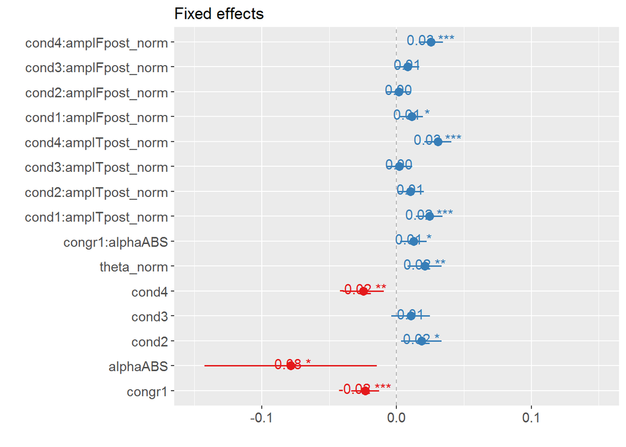

# 10 . Model validation

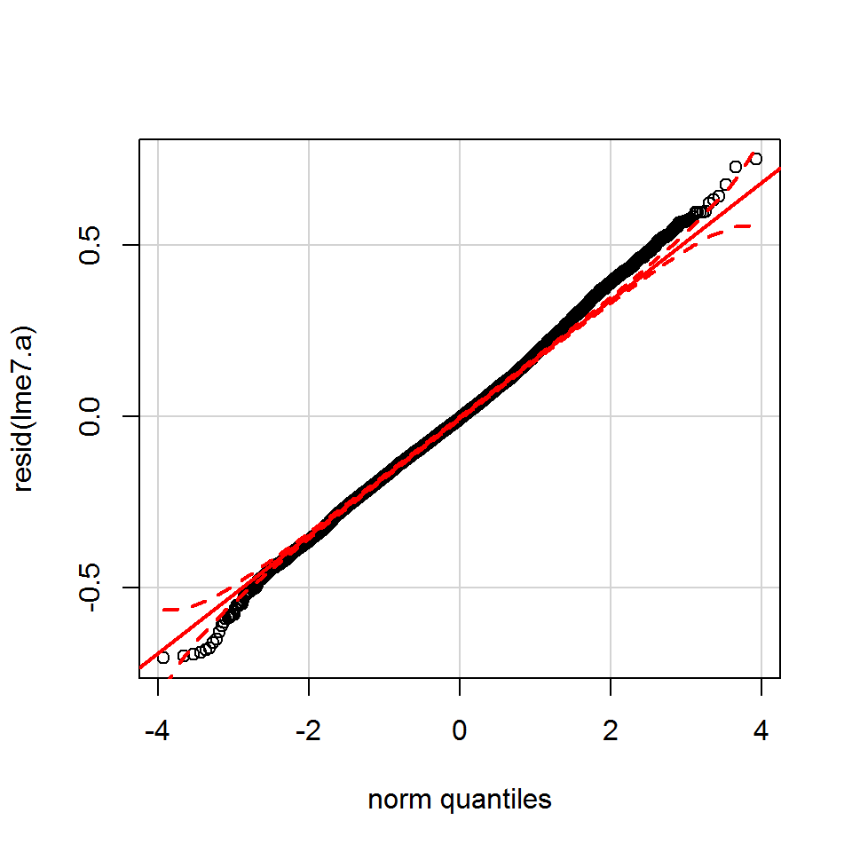

```r
qqp(resid(lme7.a))
```

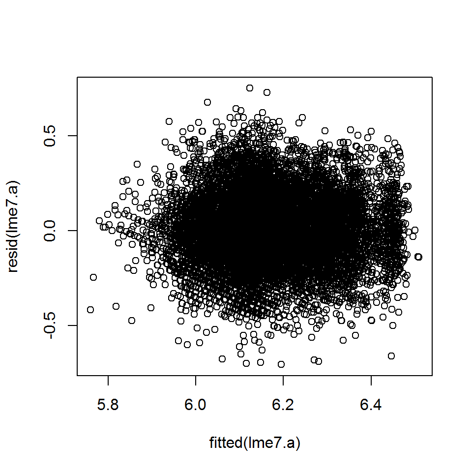

```r
plot(fitted(lme7.a),resid(lme7.a))
```

**INTERIM CONCLUSION:** Plotting residuals against the predicted values. Residuals of our best-fitting model followed a normal distribution.

# 11 . Model critisism

Removing 1.5% pf the data (potential outliers).

```r
dat2 = dat[abs(scale(resid(lme7.a))) < 2.5,]
(1-nrow(dat2)/nrow(dat))*100
```

```
## [1] 1.4408
```

```r
lme7.a2 <- lmer(RT.log ~ congr*alphaABS + cond + amplTpost_norm:cond + amplFpost_norm:cond + theta_norm + (1 + cond| Subj) + (0+amplTpost_norm|Subj) + (0+amplFpost_norm|Subj)+ (0 + theta_norm|Subj), data=dat2, REML = TRUE)


summary(lme7.a2)
```

```
## Linear mixed model fit by REML ['lmerMod']
## Formula:
## RT.log ~ congr * alphaABS + cond + amplTpost_norm:cond + amplFpost_norm:cond +
##     theta_norm + (1 + cond | Subj) + (0 + amplTpost_norm | Subj) +
##     (0 + amplFpost_norm | Subj) + (0 + theta_norm | Subj)
##    Data: dat2
##
## REML criterion at convergence: -7308.2
##
## Scaled residuals:
##     Min      1Q  Median      3Q     Max
## -2.6745 -0.6736 -0.0323  0.6369  2.7120
##
## Random effects:
##  Groups   Name           Variance  Std.Dev. Corr
##  Subj     (Intercept)    1.119e-02 0.105790
##           cond2          9.667e-04 0.031092 -0.09
##           cond3          5.885e-04 0.024258 -0.04  0.35
##           cond4          7.398e-04 0.027199  0.05  0.84  0.18
##  Subj.1   amplTpost_norm 2.018e-04 0.014207
##  Subj.2   amplFpost_norm 5.193e-05 0.007206
##  Subj.3   theta_norm     8.950e-04 0.029916
##  Residual                3.020e-02 0.173771
## Number of obs: 11629, groups:  Subj, 22
##
## Fixed effects:
##                        Estimate Std. Error t value
## (Intercept)           6.2308994  0.0355403  175.32
## congr1               -0.0228473  0.0050680   -4.51
## alphaABS             -0.0786336  0.0332791   -2.36
## cond2                 0.0211240  0.0080718    2.62
## cond3                 0.0123190  0.0069744    1.77
## cond4                -0.0219805  0.0074426   -2.95
## theta_norm            0.0209186  0.0066343    3.15
## congr1:alphaABS       0.0107349  0.0047933    2.24
## cond1:amplTpost_norm  0.0280913  0.0047815    5.87
## cond2:amplTpost_norm  0.0101128  0.0048025    2.11
## cond3:amplTpost_norm  0.0001524  0.0047151    0.03
## cond4:amplTpost_norm  0.0317427  0.0049183    6.45
## cond1:amplFpost_norm  0.0111116  0.0039247    2.83
## cond2:amplFpost_norm  0.0031361  0.0040727    0.77
## cond3:amplFpost_norm  0.0068498  0.0039458    1.74
## cond4:amplFpost_norm  0.0237022  0.0041361    5.73
```

```
##
## Correlation matrix not shown by default, as p = 16 > 12.
## Use print(x, correlation=TRUE)  or
##   vcov(x)     if you need it
```

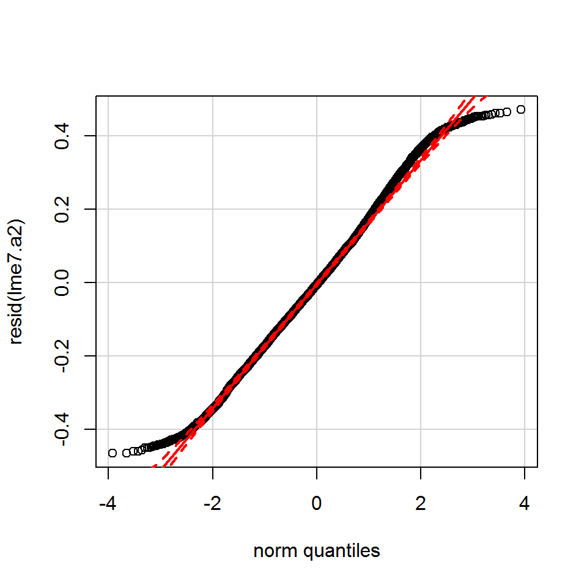

```r
qqp(resid(lme7.a2))
```

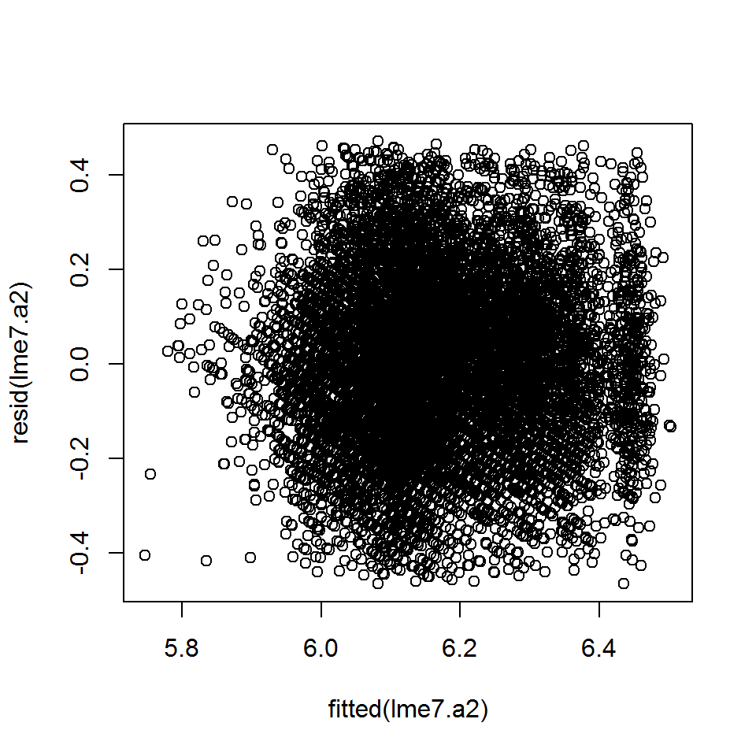

```r
plot(fitted(lme7.a2),resid(lme7.a2))
```

**CONCLUSION:** Removing 1.5% of the data did not compromise the model fit, and the significance of the fixed effects did not change.